# HDAT9600 Final Assignment Data Preparation Details

```r
check("SaO2")
```

```
##       SaO2
##  Min.   : 33.00
##  1st Qu.: 96.00
##  Median : 98.00
##  Mean   : 96.88
##  3rd Qu.: 98.00
##  Max.   :100.00
```

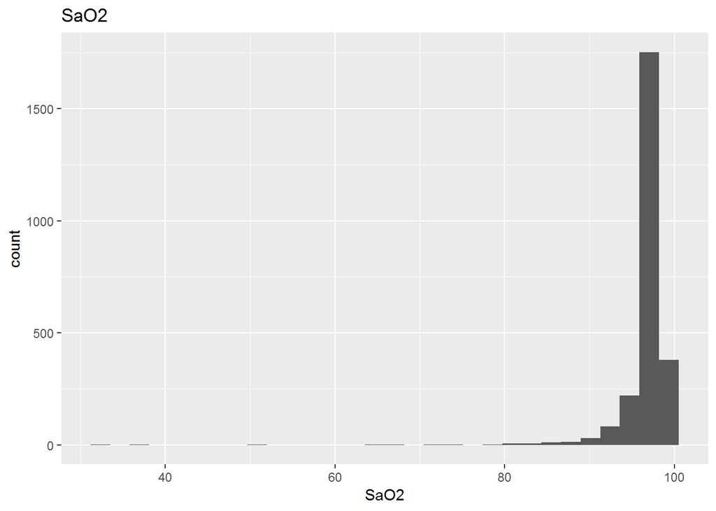

```r
check("Albumin")
```

```
##     Albumin
##  Min.   :1.100
##  1st Qu.:2.500
##  Median :3.000
##  Mean   :2.982
##  3rd Qu.:3.500
##  Max.   :5.300
```

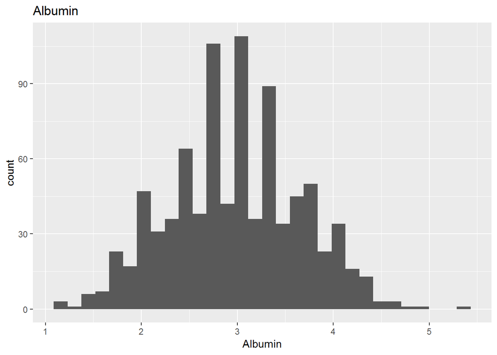

```r
check("ALP")
```

```
##       ALP
##  Min.   :  19.0
##  1st Qu.:  59.0
##  Median :  81.0
##  Mean   : 110.7
##  3rd Qu.: 120.0
##  Max.   :1504.0
```

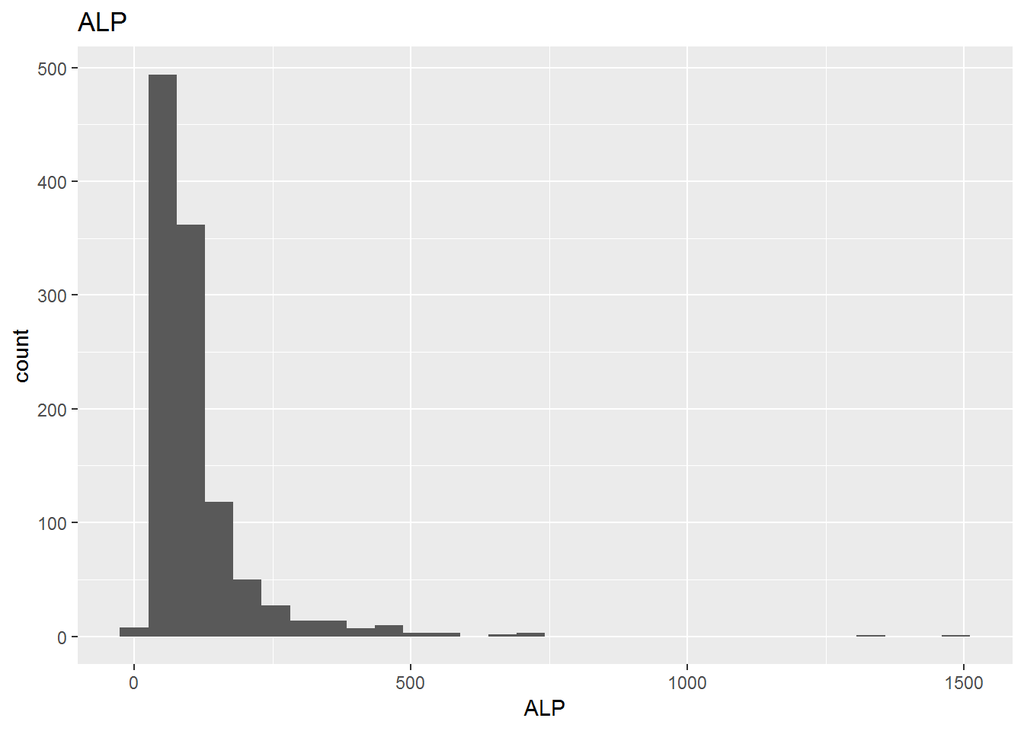

```r
check("ALT")
```

```
##       ALT
##  Min.   :    1.0
##  1st Qu.:   19.0
##  Median :   38.0
##  Mean   :  283.8
##  3rd Qu.:  123.0
##  Max.   :10440.0
```

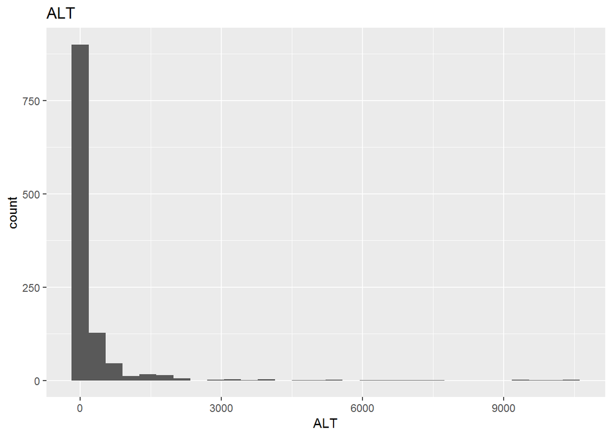

```r
check("AST")
```

```
##       AST
##  Min.   :    5.0
##  1st Qu.:   28.0
##  Median :   58.5
##  Mean   :  388.1
##  3rd Qu.:  172.8
##  Max.   :16040.0
```

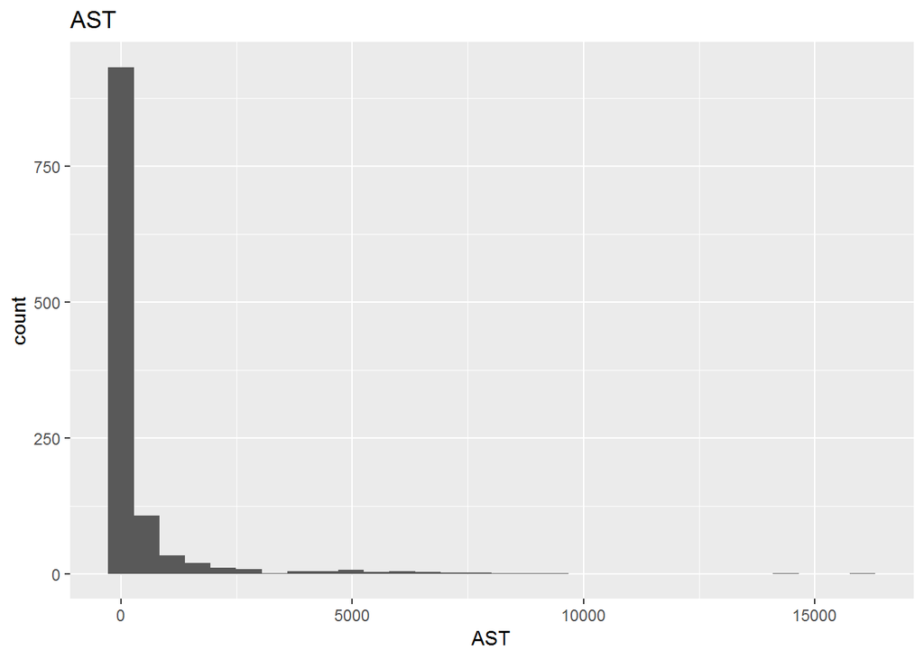

```r
check("Bilirubin")
```

```
##    Bilirubin
##  Min.   : 0.100
##  1st Qu.: 0.500
##  Median : 0.800
##  Mean   : 2.891
##  3rd Qu.: 2.200
##  Max.   :45.900
```

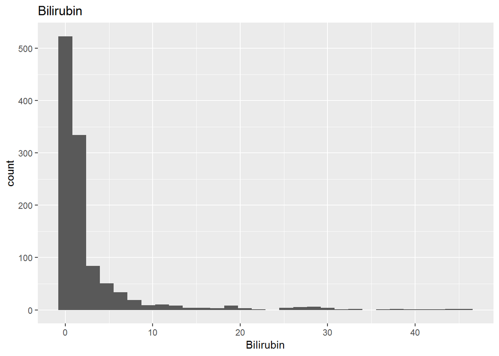

```r
check("Lactate")
```

```
##     Lactate
##  Min.   : 0.300
##  1st Qu.: 1.500
##  Median : 2.300
##  Mean   : 3.129
##  3rd Qu.: 3.800
##  Max.   :29.300
```

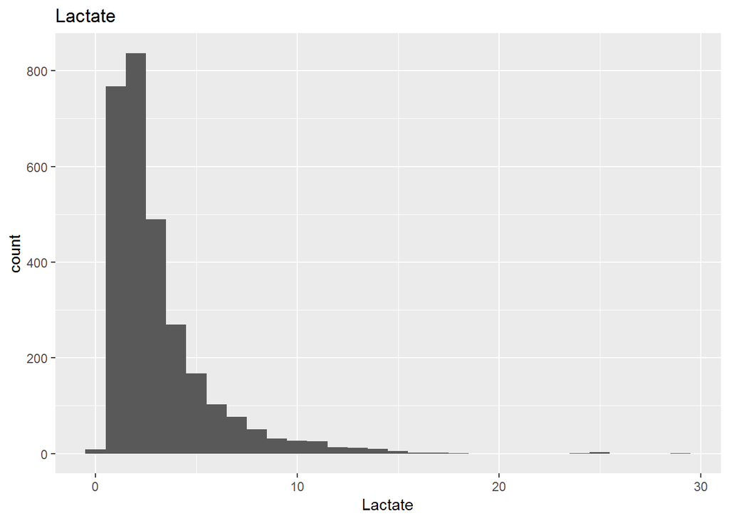

```r
check("Cholesterol")
```

```
##   Cholesterol
##  Min.   : 59.0
##  1st Qu.:123.0
##  Median :154.0
##  Mean   :158.3
##  3rd Qu.:186.0
##  Max.   :330.0
```

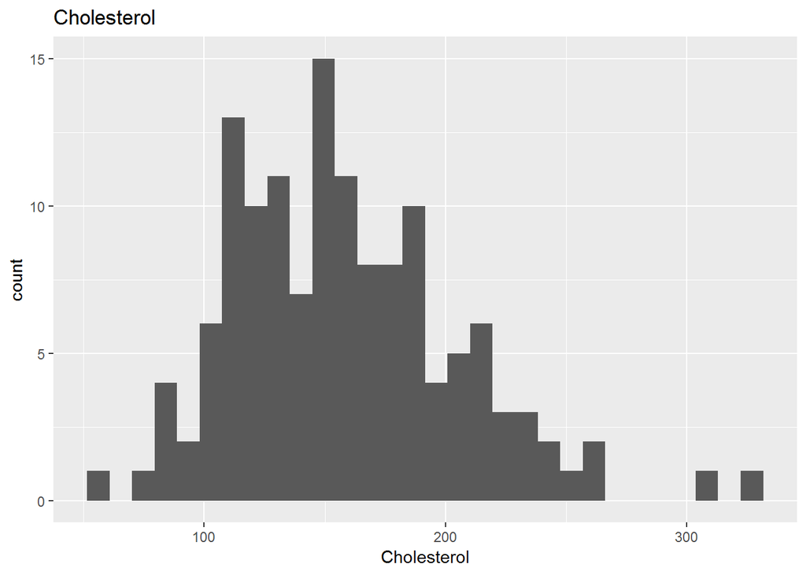

```r
check("TroponinI")
```

```
##    TroponinI
##  Min.   : 0.300
##  1st Qu.: 1.000
##  Median : 2.600
##  Mean   : 6.758
##  3rd Qu.: 8.800
##  Max.   :43.400
```

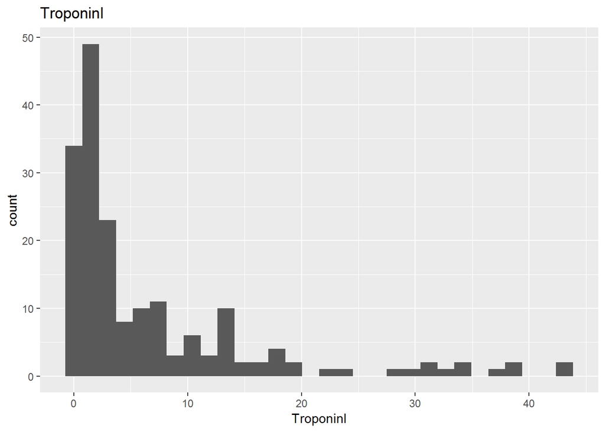

```r
check("TroponinT")
```

```
##    TroponinT
##  Min.   : 0.010
##  1st Qu.: 0.060
##  Median : 0.170
##  Mean   : 1.093
##  3rd Qu.: 0.830
##  Max.   :24.460
```

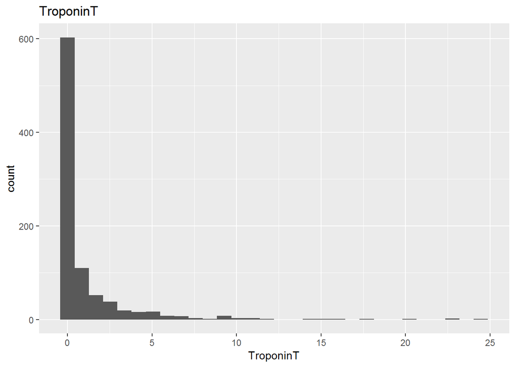

OK, after reviewing those, we see that several *Parameters* have obviously incorrect values which need to be trimmed, and quite a few have values of zero (as well as -1) which need to be set to missing (NA). That is done in a later stage (see below).

```r
# before calculating trimmed means, we set zero or negative values to missing, and set a
# few extreme values for some Parameters to missing also
trimmed_events_first_24hrs <- events_first_24hrs %>%
                              mutate(Value = case_when(Parameter == "Height" & Value < 10 ~ NA_real_,
                                                        Parameter == "Temp" & Value < 20 ~ NA_real_,
                                                        Parameter == "pH" & Value > 9 ~ NA_real_,
                                                        Parameter %in% c("Weight",
                                                                         "NIDiasABP",
                                                                         "NIMAP",
                                                                         "NISysABP",
                                                                         "DiasABP",
                                                                         "MAP",
                                                                         "SysABP",
                                                                         "RespRate",
                                                                         "BUN",
                                                                         "Creatinine",
                                                                         "Platelets",
                                                                         "WBC") & Value <= 0 ~ NA_real_,
                                                        TRUE ~ Value))
```

### Stage 4 - calculate minimum and maximum values

Next, for each patient, we calculate the minimum and maximum values for each Parameter. We also calculate the trimmed mean for each Parameter across all patients.

```r
# calculate the minimum and maximum value in the first 24 hrs in ICU for
# each Parameter (variable) for each patient
patient_minmax_first_24hrs <- trimmed_events_first_24hrs %>%
                              group_by(RecordID, Parameter) %>%
                              summarise(patient_min_value = min(Value, na.rm=TRUE),
                                        patient_max_value = max(Value, na.rm = TRUE)) %>%
                              ungroup()

# calculate the overall trimmed (robust) means for each Parameter (variable) for all patients
# for the first 24 hrs in ICU
# this results in just one row containing all the trimmed means values for each variable as a column
overall_trimmed_mean_values_first_24hrs <- trimmed_events_first_24hrs %>%
                                  group_by(Parameter) %>%
                                  summarise(overall_mean_value = mean(Value, trim=0.05, na.rm=TRUE)) %>%
                                  ungroup() %>%
                                  spread(Parameter, overall_mean_value) %>%
                                  rename_all(function(.) {paste(.,"overall_trimmed_mean",sep="_")})
```

### Stage 5 - pivot into one row per patient

```r
# convert one row per Parameter into one column per Parameter
# start with a data frame containing one row per Patient per Parameter,
# each row containing the minimum and maximum vlaue of that Parameter for
# that patient in the first 24 hrs in ICU
minima <- patient_minmax_first_24hrs %>%
          # remove the maximum value column
          select(-patient_max_value) %>%
          # convert rows per Parameter, per patient into
          # columns per Parameter, rows per patient
          spread(Parameter, patient_min_value) %>%
          # add _min to the end of each column name
          rename_all(function(.) {paste(.,"min",sep="_")}) %>%
          # undo that for the special case of the RecordID column
          rename(RecordID = RecordID_min)

# same as above but for maxima, not minima
maxima <- patient_minmax_first_24hrs %>%
          select(-patient_min_value) %>%
          spread(Parameter, patient_max_value) %>%
          rename_all(function(.) {paste(.,"max",sep="_")}) %>%
          rename(RecordID = RecordID_max)

# join all the data frames together, start with the minima data frame
icu_patients <- minima %>%
                # join that to the maxima, on a per patient basis
                # (each value of RecordID is one patient)
                left_join(maxima, by="RecordID") %>%
                # rename some columns where minimum and maximum are the same
                rename(Gender = Gender_max,
                       Age = Age_max,
                       Height = Height_max,
                       ICUType = ICUType_max) %>%
                # delete the redundant minimum versions of these columns,
                # and also delete the MechVent columns which are almost all missing
                select(-Gender_min, -Age_min, -Height_min, -ICUType_min,
                       -MechVent_min, -MechVent_max) %>%
                # convert some categorical columns to factors with labels
                mutate(Gender = factor(Gender, levels=0:1, labels=c("Female", "Male")),
                       ICUType = factor(ICUType, levels=1:4,
                                        labels=c("Coronary Care Unit",
                                                 "Cardiac Surgery Recovery Unit",
                                                 "Medical ICU", "Surgical ICU")))

# check that these all have the same numbers of rows
nrow(minima)
```

```
## [1] 2061
```

```r
nrow(maxima)
```

```
## [1] 2061
```

```r
nrow(icu_patients)
```

```
## [1] 2061
```

### Stage 6 - imputation of missing values

There are many missing values in the data frames (as is typical of clinical data). In order to simplify the assignment tasks, we will **impute** all missing values, without regard for what proportion of values are missing for each variable. This is not strictly best practice, but has been done to allow students to use all (or at least more) rows of the data for the purposes of the assignment. There is no need for HDAT9600 students to understand the details of the MICE imputation being performed in this step. Imputation is covered in HDAT9700 course, for those taking it.

However, the imputation process is not perfect, and several of the variables still have considerable numbers of missing values, even after imputation. One of the assignment tasks is to evaluate the degree of missingness of the variables and make some decisions about which to use in your statistical models.

Two data frames are saved to RDS files: `icu_patients_df0` contains the prepared data, prior to imputation, `icu_patients_df1` contains the prepared data, following imputation.

```r
library(mice)

# impute missing data with MICE (but not all columns)
imp_icu_patients <- mice(icu_patients, m=2, maxit=50, printFlag = FALSE)

# summary(imp_icu_patients)

# extract orinal data, and the imputed data, into two data frames.
icu_patients_df0 <- complete(imp_icu_patients, action = 0L)
icu_patients_df1 <- complete(imp_icu_patients, action = 1L)

# function to remove infinite values which the imputation procedure may add
remove_inf <- function(df) {
  fixed_df <- df %>%
              mutate(Height = ifelse(is.infinite(Height), NA, Height),
                     Albumin_min = ifelse(is.infinite(Albumin_min), NA, Albumin_min),
                     ALP_min = ifelse(is.infinite(ALP_min), NA, ALP_min),
                     ALT_min = ifelse(is.infinite(ALT_min), NA, ALT_min),
                     AST_min = ifelse(is.infinite(AST_min), NA, AST_min),
                     Bilirubin_min = ifelse(is.infinite(Bilirubin_min), NA, Bilirubin_min),
                     BUN_min = ifelse(is.infinite(BUN_min), NA, BUN_min),
                     Cholesterol_min = ifelse(is.infinite(Cholesterol_min), NA, Cholesterol_min),
                     Creatinine_min = ifelse(is.infinite(Creatinine_min), NA, Creatinine_min),
                     DiasABP_min = ifelse(is.infinite(DiasABP_min), NA, DiasABP_min),
                     FiO2_min = ifelse(is.infinite(FiO2_min), NA, FiO2_min),
                     GCS_min = ifelse(is.infinite(GCS_min), NA, GCS_min),
                     Glucose_min = ifelse(is.infinite(Glucose_min), NA, Glucose_min),
                     HCO3_min = ifelse(is.infinite(HCO3_min), NA, HCO3_min),
                     HCT_min = ifelse(is.infinite(HCT_min), NA, HCT_min),
                     HR_min = ifelse(is.infinite(HR_min), NA, HR_min),
                     K_min = ifelse(is.infinite(K_min), NA, K_min),
                     Lactate_min = ifelse(is.infinite(Lactate_min), NA, Lactate_min),
                     MAP_min = ifelse(is.infinite(MAP_min), NA, MAP_min),
                     Mg_min = ifelse(is.infinite(Mg_min), NA, Mg_min),
                     Na_min = ifelse(is.infinite(Na_min), NA, Na_min),
                     NIDiasABP_min = ifelse(is.infinite(NIDiasABP_min), NA, NIDiasABP_min),
                     NIMAP_min = ifelse(is.infinite(NIMAP_min), NA, NIMAP_min),
                     NISysABP_min = ifelse(is.infinite(NISysABP_min), NA, NISysABP_min),
                     PaCO2_min = ifelse(is.infinite(PaCO2_min), NA, PaCO2_min),
                     PaO2_min = ifelse(is.infinite(PaO2_min), NA, PaO2_min),
                     pH_min = ifelse(is.infinite(pH_min), NA, pH_min),
                     Platelets_min = ifelse(is.infinite(Platelets_min), NA, Platelets_min),
                     RespRate_min = ifelse(is.infinite(RespRate_min), NA, RespRate_min),
                     pH_min = ifelse(is.infinite(pH_min), NA, pH_min),
                     SaO2_min = ifelse(is.infinite(SaO2_min), NA, SaO2_min),
                     SysABP_min = ifelse(is.infinite(SysABP_min), NA, SysABP_min),
                     Temp_min = ifelse(is.infinite(Temp_min), NA, Temp_min),
                     TroponinI_min = ifelse(is.infinite(TroponinI_min), NA, TroponinI_min),
                     TroponinT_min = ifelse(is.infinite(TroponinT_min), NA, TroponinT_min),
                     Urine_min = ifelse(is.infinite(Urine_min), NA, Urine_min),
                     WBC_min = ifelse(is.infinite(WBC_min), NA, WBC_min),
                     Weight_min = ifelse(is.infinite(Weight_min), NA, Weight_min),
                     Albumin_max = ifelse(is.infinite(Albumin_max), NA, Albumin_max),
                     ALP_max = ifelse(is.infinite(ALP_max), NA, ALP_max),
                     ALT_max = ifelse(is.infinite(ALT_max), NA, ALT_max),
                     AST_max = ifelse(is.infinite(AST_max), NA, AST_max),
                     Bilirubin_max = ifelse(is.infinite(Bilirubin_max), NA, Bilirubin_max),
                     BUN_max = ifelse(is.infinite(BUN_max), NA, BUN_max),
                     Cholesterol_max = ifelse(is.infinite(Cholesterol_max), NA, Cholesterol_max),
                     Creatinine_max = ifelse(is.infinite(Creatinine_max), NA, Creatinine_max),
                     DiasABP_max = ifelse(is.infinite(DiasABP_max), NA, DiasABP_max),
                     FiO2_max = ifelse(is.infinite(FiO2_max), NA, FiO2_max),
                     GCS_max = ifelse(is.infinite(GCS_max), NA, GCS_max),
                     Glucose_max = ifelse(is.infinite(Glucose_max), NA, Glucose_max),
                     HCO3_max = ifelse(is.infinite(HCO3_max), NA, HCO3_max),
                     HCT_max = ifelse(is.infinite(HCT_max), NA, HCT_max),
                     HR_max = ifelse(is.infinite(HR_max), NA, HR_max),
                     K_max = ifelse(is.infinite(K_max), NA, K_max),
                     Lactate_max = ifelse(is.infinite(Lactate_max), NA, Lactate_max),
                     MAP_max = ifelse(is.infinite(MAP_max), NA, MAP_max),
                     Mg_max = ifelse(is.infinite(Mg_max), NA, Mg_max),
                     Na_max = ifelse(is.infinite(Na_max), NA, Na_max),
                     NIDiasABP_max = ifelse(is.infinite(NIDiasABP_max), NA, NIDiasABP_max),
                     NIMAP_max = ifelse(is.infinite(NIMAP_max), NA, NIMAP_max),
                     NISysABP_max = ifelse(is.infinite(NISysABP_max), NA, NISysABP_max),
                     PaCO2_max = ifelse(is.infinite(PaCO2_max), NA, PaCO2_max),
                     PaO2_max = ifelse(is.infinite(PaO2_max), NA, PaO2_max),
                     pH_max = ifelse(is.infinite(pH_max), NA, pH_max),
                     Platelets_max = ifelse(is.infinite(Platelets_max), NA, Platelets_max),
                     RespRate_max = ifelse(is.infinite(RespRate_max), NA, RespRate_max),
                     pH_max = ifelse(is.infinite(pH_max), NA, pH_max),
                     SaO2_max = ifelse(is.infinite(SaO2_max), NA, SaO2_max),
                     SysABP_max = ifelse(is.infinite(SysABP_max), NA, SysABP_max),
                     Temp_max = ifelse(is.infinite(Temp_max), NA, Temp_max),
                     TroponinI_max = ifelse(is.infinite(TroponinI_max), NA, TroponinI_max),
                     TroponinT_max = ifelse(is.infinite(TroponinT_max), NA, TroponinT_max),
                     Urine_max = ifelse(is.infinite(Urine_max), NA, Urine_max),
                     WBC_max = ifelse(is.infinite(WBC_max), NA, WBC_max),
                     Weight_max = ifelse(is.infinite(Weight_max), NA, Weight_max))
  return(fixed_df)
}

# call the function on the imputed datasets
icu_patients_df1 <- remove_inf(icu_patients_df1)
```

### Stage 7 - add overall trimmed means

```r
compute_diffs <- function(icu_df) {
  icu_df_with_diffs <- icu_df %>%
                # add the trimmed overall means to every row
                crossing(overall_trimmed_mean_values_first_24hrs) %>%
                # calculate the maximum absolute difference from the trimmed overal mean for each variable
                mutate(Albumin_diff = pmax(abs(Albumin_overall_trimmed_mean - Albumin_min),
                                           abs(Albumin_overall_trimmed_mean - Albumin_max), na.rm = TRUE),
                       ALP_diff = pmax(abs(ALP_overall_trimmed_mean - ALP_min),
                                           abs(ALP_overall_trimmed_mean - ALP_max), na.rm = TRUE),
                       ALT_diff = pmax(abs(ALT_overall_trimmed_mean - ALT_min),
                                           abs(ALT_overall_trimmed_mean - ALT_max), na.rm = TRUE),
                       AST_diff = pmax(abs(AST_overall_trimmed_mean - AST_min),
                                           abs(AST_overall_trimmed_mean - AST_max), na.rm = TRUE),
                       Bilirubin_diff = pmax(abs(Bilirubin_overall_trimmed_mean - Bilirubin_min),
                                           abs(Bilirubin_overall_trimmed_mean - Bilirubin_max), na.rm = TRUE),
                       BUN_diff = pmax(abs(BUN_overall_trimmed_mean - BUN_min),
                                           abs(BUN_overall_trimmed_mean - BUN_max), na.rm = TRUE),
                       Cholesterol_diff = pmax(abs(Cholesterol_overall_trimmed_mean - Cholesterol_min),
                                           abs(Cholesterol_overall_trimmed_mean - Cholesterol_max), na.rm = TRUE),
                       Creatinine_diff = pmax(abs(Creatinine_overall_trimmed_mean - Creatinine_min),
                                           abs(Creatinine_overall_trimmed_mean - Creatinine_max), na.rm = TRUE),
                       DiasABP_diff = pmax(abs(DiasABP_overall_trimmed_mean - DiasABP_min),
                                           abs(DiasABP_overall_trimmed_mean - DiasABP_max), na.rm = TRUE),
                       FiO2_diff = pmax(abs(FiO2_overall_trimmed_mean - FiO2_min),
                                           abs(FiO2_overall_trimmed_mean - FiO2_max), na.rm = TRUE),
                       GCS_diff = pmax(abs(GCS_overall_trimmed_mean - GCS_min),
                                           abs(GCS_overall_trimmed_mean - GCS_max), na.rm = TRUE),
                       Glucose_diff = pmax(abs(Glucose_overall_trimmed_mean - Glucose_min),
                                           abs(Glucose_overall_trimmed_mean - Glucose_max), na.rm = TRUE),
                       HCO3_diff = pmax(abs(HCO3_overall_trimmed_mean - HCO3_min),
                                           abs(HCO3_overall_trimmed_mean - HCO3_max), na.rm = TRUE),
                       HCT_diff = pmax(abs(HCT_overall_trimmed_mean - HCT_min),
                                           abs(HCT_overall_trimmed_mean - HCT_max), na.rm = TRUE),
                       HR_diff = pmax(abs(HR_overall_trimmed_mean - HR_min),
                                           abs(HR_overall_trimmed_mean - HR_max), na.rm = TRUE),
                       K_diff = pmax(abs(K_overall_trimmed_mean - K_min),
                                           abs(K_overall_trimmed_mean - K_max), na.rm = TRUE),
                       Lactate_diff = pmax(abs(Lactate_overall_trimmed_mean - Lactate_min),
                                           abs(Lactate_overall_trimmed_mean - Lactate_max), na.rm = TRUE),
                       MAP_diff = pmax(abs(MAP_overall_trimmed_mean - MAP_min),
                                           abs(MAP_overall_trimmed_mean - MAP_max), na.rm = TRUE),
                       Mg_diff = pmax(abs(Mg_overall_trimmed_mean - Mg_min),
                                           abs(Mg_overall_trimmed_mean - Mg_max), na.rm = TRUE),
                       Na_diff = pmax(abs(Na_overall_trimmed_mean - Na_min),
                                           abs(Na_overall_trimmed_mean - Na_max), na.rm = TRUE),
                       NIDiasABP_diff = pmax(abs(NIDiasABP_overall_trimmed_mean - NIDiasABP_min),
                                           abs(NIDiasABP_overall_trimmed_mean - NIDiasABP_max), na.rm = TRUE),
                       NIMAP_diff = pmax(abs(NIMAP_overall_trimmed_mean - NIMAP_min),
                                           abs(NIMAP_overall_trimmed_mean - NIMAP_max), na.rm = TRUE),
                       NISysABP_diff = pmax(abs(NISysABP_overall_trimmed_mean - NISysABP_min),
                                           abs(NISysABP_overall_trimmed_mean - NISysABP_max), na.rm = TRUE),
                       PaCO2_diff = pmax(abs(PaCO2_overall_trimmed_mean - PaCO2_min),
                                           abs(PaCO2_overall_trimmed_mean - PaCO2_max), na.rm = TRUE),
                       PaO2_diff = pmax(abs(PaO2_overall_trimmed_mean - PaO2_min),
                                           abs(PaO2_overall_trimmed_mean - PaO2_max), na.rm = TRUE),
                       pH_diff = pmax(abs(pH_overall_trimmed_mean - pH_min),
                                           abs(pH_overall_trimmed_mean - pH_max), na.rm = TRUE),
                       Platelets_diff = pmax(abs(Platelets_overall_trimmed_mean - Platelets_min),
                                           abs(Platelets_overall_trimmed_mean - Platelets_max), na.rm = TRUE),
                       RespRate_diff = pmax(abs(RespRate_overall_trimmed_mean - RespRate_min),
                                           abs(RespRate_overall_trimmed_mean - RespRate_max), na.rm = TRUE),
                       SaO2_diff = pmax(abs(SaO2_overall_trimmed_mean - SaO2_min),
                                           abs(SaO2_overall_trimmed_mean - SaO2_max), na.rm = TRUE),
                       SysABP_diff = pmax(abs(SysABP_overall_trimmed_mean - SysABP_min),
                                           abs(SysABP_overall_trimmed_mean - SysABP_max), na.rm = TRUE),
                       Temp_diff = pmax(abs(Temp_overall_trimmed_mean - Temp_min),
                                           abs(Temp_overall_trimmed_mean - Temp_max), na.rm = TRUE),
                       TroponinI_diff = pmax(abs(TroponinI_overall_trimmed_mean - TroponinI_min),
                                           abs(TroponinI_overall_trimmed_mean - TroponinI_max), na.rm = TRUE),
                       TroponinT_diff = pmax(abs(TroponinT_overall_trimmed_mean - TroponinT_min),
                                           abs(TroponinT_overall_trimmed_mean - TroponinT_max), na.rm = TRUE),
                       Urine_diff = pmax(abs(Urine_overall_trimmed_mean - Urine_min),
                                           abs(Urine_overall_trimmed_mean - Urine_max), na.rm = TRUE),
                       WBC_diff = pmax(abs(WBC_overall_trimmed_mean - WBC_min),
                                           abs(WBC_overall_trimmed_mean - WBC_max), na.rm = TRUE),
                       Weight_diff = pmax(abs(Weight_overall_trimmed_mean - Weight_min),
                                           abs(Weight_overall_trimmed_mean - Weight_max), na.rm = TRUE)
                       ) %>%
                # remove the *_overall_trimmed_mean columns
                select(-ends_with("_overall_trimmed_mean"))
  return(icu_df_with_diffs)
}

# call that function for each of the two versions of the data
icu_patients_df0 <- compute_diffs(icu_patients_df0)
icu_patients_df1 <- compute_diffs(icu_patients_df1)
```

### Stage 8 - add outcome columns and clean up

This stage joins the outcome columns on a per-patient basis, renames a few columns to make them easier to use and does some tidying up, and then sorts the columns into alphabetical order but puts the outcome columns at the “front”.

We also create two new columns called `Days` and `Status`. Days contains the same value as the `Survival` column if `Survival` is not missing (`NA`), otherwise it contains the maximum value of `Survival`. `Status` is set to 0 if `Survival` is missing, otherwise it is set to 1.

Thus, `Days` contains the time to death (in days) if the patient had died by the end of follow-up, or it contains the follow-up time (the censoring time) if the patient did not die during follow-up. For the purposes of this assignment, we have arbitrarily taken the follow-up time for all patients to be the maximum time to death in any patient (because duration of follow-up was not provided in the data).

```r
# define function to carry out tasks
join_outcomes <- function(icu_df) {
  icu_df_with_outcomes <- icu_df %>%
                            # join the outcomes data frame
                            left_join(outcomes, by="RecordID") %>%
                            # rename a few columns to make them easier to use (remove dashes from names)
                            rename(in_hospital_death = "In-hospital_death",
                                   SAPS1 = "SAPS-I") %>%
                            # fix missing for a few more variables
                            mutate(SAPS1 = ifelse(SAPS1 != -1, SAPS1, NA),
                                   Survival = ifelse(Survival == -1, NA, Survival)) %>%
                            # create Days and Status columns
                            mutate(Days = ifelse(is.na(Survival), max(Survival, na.rm = TRUE), Survival),
                                   Status = ifelse(is.na(Survival), FALSE, TRUE)) %>%
                            #  re-order the columns in alphabetical order
                            select(sort(names(.))) %>%
                            # but move the RecordID and the SAPS, SOFA and outcome columns to the "front"
                            select(RecordID, Length_of_stay, SAPS1, SOFA,
                                   Survival, in_hospital_death, Days, Status, everything())

  return(icu_df_with_outcomes)
}

# call that function for each of the three versions of the data
icu_patients_df0 <- join_outcomes(icu_patients_df0)
icu_patients_df1 <- join_outcomes(icu_patients_df1)

# save each version to an rds file.
saveRDS(icu_patients_df0, "icu_patients_df0.rds")
saveRDS(icu_patients_df1, "icu_patients_df1.rds")
```

All of the above takes a while to run. This just posts a notification on your desktop when it has finished.

```r
if (require("notifier")) {
  notifier::notify("Finished!")
}
```